# pMax_alternatives

Tom Booker

16/12/2020

## R Markdown

rm(list = ls() )

Here I’ll try and put the idea I had for a convergence statistic into practice

In this test, you’d have a p-value for each ortholog from each of k species.

So you’ll have a vector of k pVals for each gene.

We structure the statistic like this:

Rank the pVals from lowest to highest Starting from, the highest ask, what is the prob. that you’d see k-1 values lower than p[k] That’s binomial – pbinom(k-1, k-1, p[k]) For the second highest p, it’d be pbinom(k-2, k-2, p[k-1]). However, we’re only looking at values that are lower than p[k] so we’d need to condition the probabilities on the fact that we’re now looking for things over a constrained range.

```r
## For example, with 4 species you might have a case like this.
vec <- c(0.001,0.02,0.03,0.4)
## The prob of getting 4 values less than 0.4 is:
dbinom(4,4,0.4)
```

```
## [1] 0.0256
```

```r
## The prob of getting 3 values less than 0.03 is:
dbinom(3,3,0.03)
```

```
## [1] 2.7e-05
```

```r
## However, we are constrained by the fact that we are only looking at things in the range 0 - 0.4, so we need to correct for that.
## If we are looking at pVals in the range [0, 1], then the probability of getting a value less than some threhsold is simply the threshold. If we are looking at values in the range [ 0, 0.5 ], the probaiblity of a random draw falling below 0.1 is 0.1/0.5 =0.2. We need to adjust the probability accordingly...
dbinom(3,3,0.03/0.4)
```

```
## [1] 0.000421875
```

```r
## The prob of getting 2 values less than or equal to 0.02 is
dbinom(2,2,0.02/0.03)
```

```
## [1] 0.4444444
```

```r
## So for the vector "vec"
## The statistic would be somwthing like this, so that small probabilities contribute more than big ones
-log(dbinom(4,4,0.4)) + -log(dbinom(3,3,0.03/0.4)) + -log(dbinom(2,2,0.02/0.03))
```

```
## [1] 12.24689
```

```r
# A generic for this could be something like:

pMax2 <- function(probValues_raw){
  pValues = sort(probValues_raw, decreasing  = TRUE)
  k = length(pValues)
  k_vec = k:2
  probVec = pValues[1:(k-1)]/c(1,pValues[1:(k-2)])
  ## dbinom is nicely vectorised, so we can do it all in one go instead of a loop
  prod(dbinom(k_vec, k_vec, probVec))
}
pMax2(vec)
```

```
## [1] 4.8e-06
```

Ok, now let’s apply this to some different data fake cases

```r
## Here're some typical non-interesting cases - random pValues
pop1 <- runif(10000)
pop2 <- runif(10000)
pop3 <- runif(10000)
pop4 <- runif(10000)
pop5 <- runif(10000)
pop6 <- runif(10000)
pop7 <- runif(10000)

M <- as.matrix( cbind(pop1,pop2,pop3, pop4, pop5, pop6 , pop7))

## Here's the matrix of random pValues
head(M)
```

```
##           pop1      pop2      pop3       pop4      pop5       pop6      pop7
## [1,] 0.8419620 0.1737903 0.1305861 0.93753771 0.1443981 0.34693934 0.5935998
## [2,] 0.8697994 0.6187271 0.2835122 0.52440583 0.6972701 0.29436359 0.1973080
## [3,] 0.9209360 0.7069259 0.2764648 0.09391404 0.8751331 0.73020044 0.2896884
## [4,] 0.8061604 0.2326065 0.1110404 0.94611160 0.7153937 0.06830614 0.8041296
## [5,] 0.6075663 0.4628202 0.5259518 0.30960304 0.9086355 0.04347942 0.9527072
## [6,] 0.3437777 0.5741669 0.3605987 0.30517085 0.8462311 0.61090117 0.2001929
```

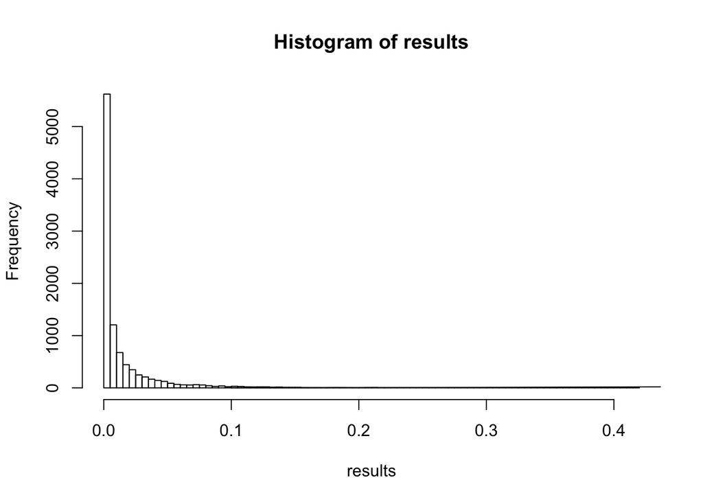

```r
## Now let's apply this new test to them and examine the distribution of the resulting logLikelihoods
results <- apply ( M, 1, function(x) pMax2(x))

hist(results, breaks  = 100)

lines( 1:300/10, dchisq(1:300/10, 6)*(10000/5), type = 'l')
```

```r
## The /5 is due to the histogram scaling that R does
```

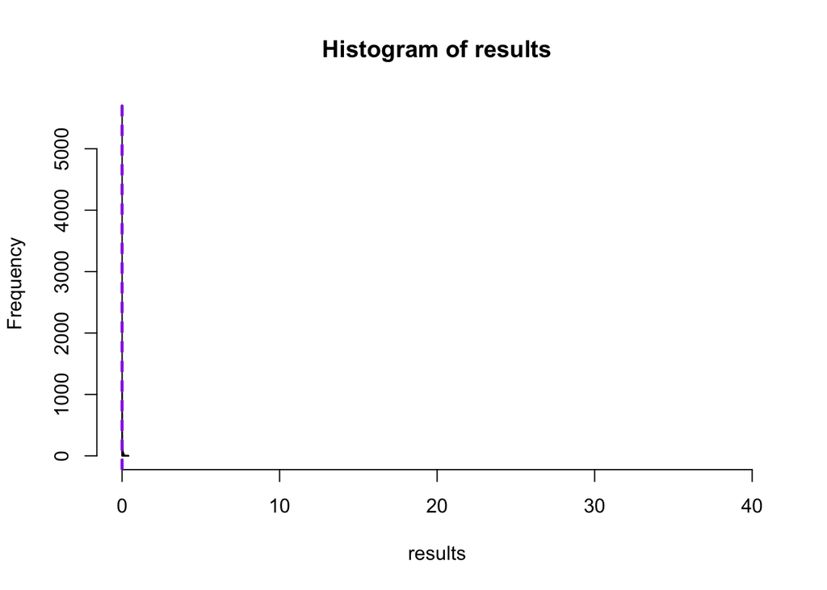

```r
hist(results, breaks  = 100,xlim = c(0,40))

# Here's a case with very strong convergence between 2 genes
test_1 <- c(c(0.0001,0.0002),runif(5))
abline(v = pMax2(test_1), col = "green", lty = 2,lwd = 2)

# Here's a case with strong convergence between 4 genes
test_2 <- c(c(0.0001,0.005, 0.0034,0.01),runif(3))
abline(v = pMax2(test_2), col = "red", lty = 2,lwd = 2)

# Here's a case with mild convergence between 2 genes
test_3 <- c(c(0.01,0.05),runif(5))
abline(v = pMax2(test_3), col = "blue", lty = 2,lwd = 2)

# Here's a case with mild convergence between all genes
test_4 <- c(0.01,0.05, 0.02,0.01,0.2, 0.15, 0.09)
abline(v = pMax2(test_4), col = "purple", lty = 2,lwd = 2)
```

Likelihood ratio tests are assumed to have a chiSq distribution. The distribution kind of looks like it’s chiSq dist. However, as it is, the test statistic is a likelihood, not a likelihood ratio. We could do the proper LRT if we had a good idea what the null hypothesis was.

I haven’t thought through what the null hypothesis is for this test. I guess it could be pMax2(rep(0.5, k)), that each gene is a uniform draw, so there’d be a 50/50 chance each time.

```r
mean(results)
```

```
## [1] 0.01575426
```

```r
pMax2(rep(0.5,7))
```

```
## [1] 0.0078125
```

However, the mean of the random distribution should be pretty close to themean of the random dist, I’d have thought.